# Machine Learning Project.

Sergey Rakhmatullin

## Summary

Following study is aimed to figure out if the devices Jawbone Up, Nike FuelBand, and Fitbit is possible to determine the correct technique of doing fitness exersizes, e.g. barbell lifts, and predict the manner of doing exersize. The exersizes were performed by six individuals and classified as five different ways of doing exersize (A,B,C,D,E) both correct and incorrect, i.e. we have classification problem and need to deliver prediction model for it and out of sample error estimations.  
Given data:  
* https://d396qusza40orc.cloudfront.net/predmachlearn/pml-training.csv (training set)  
* https://d396qusza40orc.cloudfront.net/predmachlearn/pml-testing.csv (testing set)  
Study should cover following questions:  
* how model was built,  
* how cross validation used,  
* what is expected out of sample error,  
* and why the following choices were made.  
The prediction model also should be used to predict 20 different test cases from testing set.

## Loading data and preprocessing

Downloading training and testing dataset:

```r
set.seed('123')
url<-"https://d396qusza40orc.cloudfront.net/predmachlearn/"
trainFile<-"pml-training.csv"
testFile<-"pml-testing.csv"

if(!file.exists(trainFile)) download.file(paste0(url,trainFile), destfile = trainFile, method = "curl")
if(!file.exists(testFile)) download.file(paste0(url,testFile), destfile = testFile, method = "curl")
train <- read.csv(trainFile)
test20 <- read.csv(testFile)
```

Quick view (summary(train)) on the data shows that we have many NA and blank data so we need to clean the data by removing columns with more than 95% NA or blank values in training set.

```r
test20<-test20[, (colSums(is.na(train) | train=='') < nrow(train) * 0.95)]
train<-train[, (colSums(is.na(train) | train=='') < nrow(train) * 0.95)]
```

We have large training set (19622 entries) and very small testing set (20 entries), so to estimate out-of-sample error we split our training set into 70% training and 30% testing set.

```r
require(caret)
inTrain <- createDataPartition(y=train$classe, p=0.7, list=FALSE)
training <- train[inTrain,]
testing <- train[-inTrain,]
rm(train)
dim(training); dim(testing)
```

```
## [1] 13737    60
```

```
## [1] 5885   60
```

We exclude variables that are irrelevant to our study as a features and save our features to train.feat dataset.

```r
train.feat<-training[,-c(1:6,60)]
```

## Exploratory Data analysis

I’m not going to demostrate all the feature plots that I’ve analysed but show typical examples:

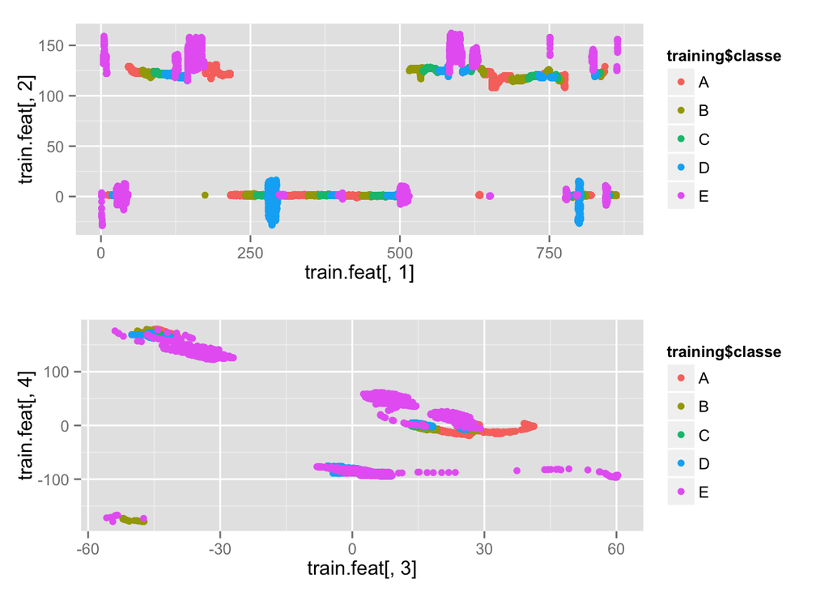

```r
library(ggplot2)
library(grid)
library(gridExtra)
q1<-qplot(train.feat[,1], train.feat[,2], colour=training$classe)
q2<-qplot(train.feat[,3], train.feat[,4], colour=training$classe)
grid.arrange(q1, q2)
```

We can see cluster structure for different classes with no almost no regression pattern, that can lead us to conclusion that be can achive better results with decision trees algorithms

## Model Selection Strategy

### Method selection

We are going to try different algorithm on small part of training dataset to figure out accuracy of different methods.

```r
inSmall <- createDataPartition(y=training$classe, p=0.1, list=FALSE)
small <- training[inSmall,]
small.feat <-train.feat[inSmall,]
pretest <- training[-inSmall,]
pretest.feat <-train.feat[-inSmall,]
```

Trying classification tree method

```r
smallFit1 <- train(small.feat, small$classe, method="rpart")
pretest1 <- predict(smallFit1, newdata=pretest.feat)
confusionMatrix(pretest$classe, pretest1)
```

```
## Confusion Matrix and Statistics
##
##           Reference
## Prediction    A    B    C    D    E
##          A 2761   57  690    0    7
##          B  445  794 1153    0    0
##          C  241   73 1842    0    0
##          D  248  360 1320    0   98
##          E   72  163  659    0 1378
##
## Overall Statistics
##
##                Accuracy : 0.5481
##                  95% CI : (0.5393, 0.5569)
##     No Information Rate : 0.4582
##     P-Value [Acc > NIR] : < 2.2e-16
##
##                   Kappa : 0.427
##  Mcnemar's Test P-Value : < 2.2e-16
##
## Statistics by Class:
##
##                      Class: A Class: B Class: C Class: D Class: E
## Sensitivity            0.7329  0.54872   0.3252       NA   0.9292
## Specificity            0.9123  0.85358   0.9531   0.8361   0.9178
## Pos Pred Value         0.7855  0.33194   0.8544       NA   0.6065
## Neg Pred Value         0.8863  0.93450   0.6255       NA   0.9896
## Prevalence             0.3047  0.11706   0.4582   0.0000   0.1200
## Detection Rate         0.2234  0.06423   0.1490   0.0000   0.1115
## Detection Prevalence   0.2844  0.19351   0.1744   0.1639   0.1838
## Balanced Accuracy      0.8226  0.70115   0.6392       NA   0.9235
```

Fast. Out-of-sample accuracy is around 50%.

Trying LDA method

```r
smallFit1 <- train(small.feat, small$classe, method="lda")
pretest1 <- predict(smallFit1, newdata=pretest.feat)
confusionMatrix(pretest$classe, pretest1)
```

```
## Confusion Matrix and Statistics
##
##           Reference
## Prediction    A    B    C    D    E
##          A 2802  105  269  302   37
##          B  338 1434  405  120   95
##          C  171  171 1503  239   72
##          D  102   85  309 1444   86
##          E  109  378  211  193 1381
##
## Overall Statistics
##
##                Accuracy : 0.6928
##                  95% CI : (0.6846, 0.701)
##     No Information Rate : 0.2849
##     P-Value [Acc > NIR] : < 2.2e-16
##
##                   Kappa : 0.6119
##  Mcnemar's Test P-Value : < 2.2e-16
##
## Statistics by Class:
##
##                      Class: A Class: B Class: C Class: D Class: E
## Sensitivity            0.7956   0.6599   0.5573   0.6284   0.8265
## Specificity            0.9193   0.9060   0.9324   0.9422   0.9167
## Pos Pred Value         0.7972   0.5995   0.6971   0.7127   0.6078
## Neg Pred Value         0.9186   0.9259   0.8830   0.9174   0.9713
## Prevalence             0.2849   0.1758   0.2182   0.1859   0.1352
## Detection Rate         0.2267   0.1160   0.1216   0.1168   0.1117
## Detection Prevalence   0.2844   0.1935   0.1744   0.1639   0.1838
## Balanced Accuracy      0.8575   0.7829   0.7449   0.7853   0.8716
```

Very fast. Out-of-sample accuracy is around 70%.

Trying random forest method

```r
smallFit1 <- train(small.feat, small$classe, method="rf")
pretest1 <- predict(smallFit1, newdata=pretest.feat)
confusionMatrix(pretest$classe, pretest1)
```

```
## Confusion Matrix and Statistics
##
##           Reference
## Prediction    A    B    C    D    E
##          A 3495    6    0    6    8
##          B  158 2134   98    2    0
##          C    1   93 2048   14    0
##          D    4   24   34 1933   31
##          E    0   47   14   27 2184
##
## Overall Statistics
##
##                Accuracy : 0.9541
##                  95% CI : (0.9503, 0.9578)
##     No Information Rate : 0.2959
##     P-Value [Acc > NIR] : < 2.2e-16
##
##                   Kappa : 0.9419
##  Mcnemar's Test P-Value : < 2.2e-16
##
## Statistics by Class:
##
##                      Class: A Class: B Class: C Class: D Class: E
## Sensitivity            0.9554   0.9262   0.9335   0.9753   0.9825
## Specificity            0.9977   0.9743   0.9894   0.9910   0.9913
## Pos Pred Value         0.9943   0.8921   0.9499   0.9541   0.9613
## Neg Pred Value         0.9816   0.9829   0.9857   0.9953   0.9961
## Prevalence             0.2959   0.1864   0.1775   0.1603   0.1798
## Detection Rate         0.2827   0.1726   0.1657   0.1564   0.1767
## Detection Prevalence   0.2844   0.1935   0.1744   0.1639   0.1838
## Balanced Accuracy      0.9766   0.9503   0.9614   0.9832   0.9869
```

Slow. Out-of-sample accuracy is around 95%.

```r
rm(smallFit1, pretest1)
rm(pretest, pretest.feat, small, small.feat, inSmall)
```

### Cross-validation

We have found that random forest works well on our data. The next step we are going feed them 70% training set for more accuracy. Also to maximize accuracy we are going to use 4-fold cross validation in the function trainControl.

Finally we are using random forest with 4-fold cross validation

Random forests algorithm

```r
rfFit <- train(train.feat, training$classe, method="rf", trControl = trainControl(method = 'cv', number = 4))
```

### Out of Sample Error Estimation

We are going to estimate out of sample error on our remaining 30% of training test.

```r
test.feat<-testing[,-c(1:6,60)]

##Random Forest
test2 <- predict(rfFit, newdata=test.feat)
confusionMatrix(testing$classe,test2)
```

```
## Confusion Matrix and Statistics
##
##           Reference
## Prediction    A    B    C    D    E
##          A 1674    0    0    0    0
##          B    0 1139    0    0    0
##          C    0    2 1024    0    0
##          D    0    0    9  955    0
##          E    0    0    0    1 1081
##
## Overall Statistics
##
##                Accuracy : 0.998
##                  95% CI : (0.9964, 0.9989)
##     No Information Rate : 0.2845
##     P-Value [Acc > NIR] : < 2.2e-16
##
##                   Kappa : 0.9974
##  Mcnemar's Test P-Value : NA
##
## Statistics by Class:
##
##                      Class: A Class: B Class: C Class: D Class: E
## Sensitivity            1.0000   0.9982   0.9913   0.9990   1.0000
## Specificity            1.0000   1.0000   0.9996   0.9982   0.9998
## Pos Pred Value         1.0000   1.0000   0.9981   0.9907   0.9991
## Neg Pred Value         1.0000   0.9996   0.9981   0.9998   1.0000
## Prevalence             0.2845   0.1939   0.1755   0.1624   0.1837
## Detection Rate         0.2845   0.1935   0.1740   0.1623   0.1837
## Detection Prevalence   0.2845   0.1935   0.1743   0.1638   0.1839
## Balanced Accuracy      1.0000   0.9991   0.9954   0.9986   0.9999
```

## Prediction of test cases

```r
test20.feat<-test20[,-c(1:6,60)]
result <- predict(rfFit, newdata=test20.feat)
result
```

```
##  [1] B A B A A E D B A A B C B A E E A B B B
## Levels: A B C D E
```

## Conclusions

Random forest algorithm gives us 99% accuracy estimation and can be used for our purpose.